# PhoebeTeskey_GLMs

```r
library(ggplot2)
library(DHARMa)
library(MASS)
library(easystats)
library(lme4)
library(glmmTMB)
library(car)
```

GLMs

1. The data in stork.txt display the stress-induced corticosterone levels circulating in the blood of European white storks and their survival over the subsequent five years of study. Analyze the data following this structure: 1. Question, 2. Exploratory analyses, 3. Fit model, 4. Validate model, 5. Test hypothesis and assess explanatory power, and 6. Communication of results (plot + description of main results).

Question: Does corticosterone level predict survival of European white storks over a period of 5 years?

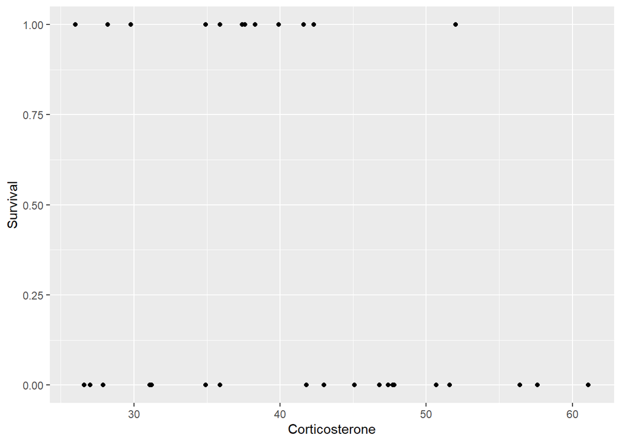

```r
#Exploratory analyses
stork <- read.table("../data_raw/stork.txt", header = T)

ggplot(stork, aes(x = Corticosterone, y = Survival))+
  geom_point()
```

Fit Model:

```r
stork.glm<-glm(Survival ~ Corticosterone, family=binomial(link="logit"), data = stork)
summary(stork.glm)
```

```
##
## Call:
## glm(formula = Survival ~ Corticosterone, family = binomial(link = "logit"),
##     data = stork)
##
## Coefficients:
##                Estimate Std. Error z value Pr(>|z|)
## (Intercept)     2.70304    1.74725   1.547   0.1219
## Corticosterone -0.07980    0.04368  -1.827   0.0677 .
## ---
## Signif. codes:  0 '***' 0.001 '**' 0.01 '*' 0.05 '.' 0.1 ' ' 1
##
## (Dispersion parameter for binomial family taken to be 1)
##
##     Null deviance: 45.234  on 33  degrees of freedom
## Residual deviance: 41.396  on 32  degrees of freedom
## AIC: 45.396
##
## Number of Fisher Scoring iterations: 4
```

Validate Model:

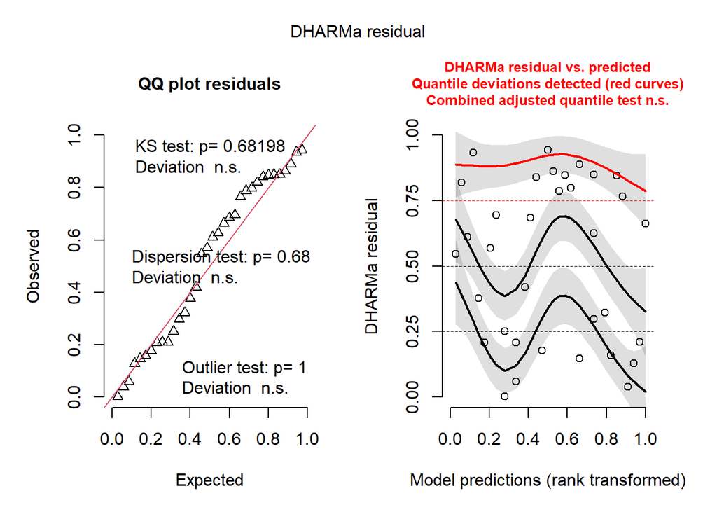

```
## Object of Class DHARMa with simulated residuals based on 250 simulations with refit = FALSE . See ?DHARMa::simulateResiduals for help.
##
## Scaled residual values: 0.6634103 0.7655982 0.8465965 0.8503342 0.6259939 0.8893231 0.7981121 0.8486897 0.7876165 0.8626401 0.9436615 0.840748 0.9343146 0.2100377 0.1285811 0.03841849 0.1588645 0.3212054 0.2972712 0.1469927 ...
```

```r
simulateResiduals(stork.glm, plot = T)
```

Test hypothesis and assess explanatory power:

```r
anova(stork.glm, test = "LRT")
```

```
## Analysis of Deviance Table
##
## Model: binomial, link: logit
##
## Response: Survival
##
## Terms added sequentially (first to last)
##
##
##                Df Deviance Resid. Df Resid. Dev Pr(>Chi)
## NULL                              33     45.234
## Corticosterone  1   3.8382        32     41.396   0.0501 .
## ---
## Signif. codes:  0 '***' 0.001 '**' 0.01 '*' 0.05 '.' 0.1 ' ' 1
```

```r
r2(stork.glm)
```

```
## # R2 for Logistic Regression
##   Tjur's R2: 0.102
```

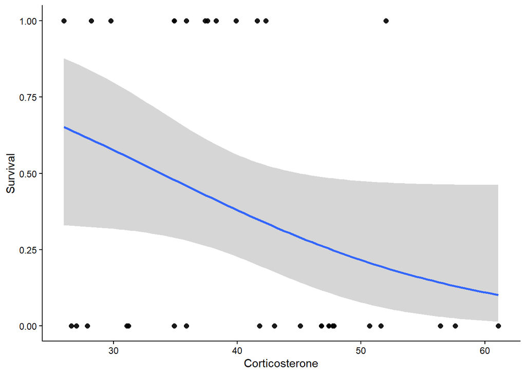

```r
ggplot(aes(x=Corticosterone, y=Survival), data=stork)+
  geom_point(size = 2, alpha = 0.9)+
  geom_smooth(method=glm, method.args = list(family = "binomial"), se=T)+
  theme_classic()
```

2. The clusters.txt dataset contains the response variable Cancers (the number of reported cancer cases per clinic) and the explanatory variable Distance (the distance from a nuclear plant to the clinic in kilometers). Analyze the data following this structure: 1. Question, 2. Exploratory analyses, 3. Fit model, 4. Validate model, 5. Test hypothesis and assess explanatory power, and 6. Communication of results (plot + description of main results).

1.) Question: Do cancer cases occur more often closer to a nuclear power plant?

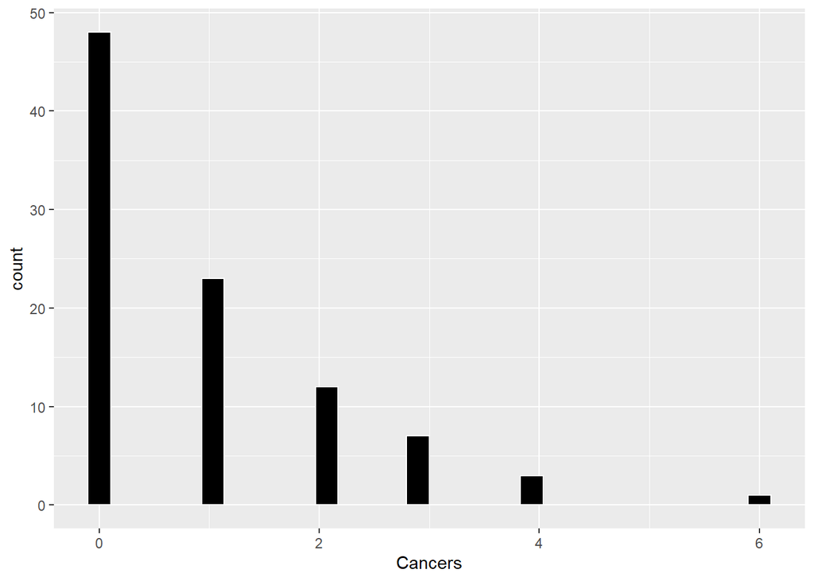

```r
#2.) Exploratory analyses

cancer <- read.table("../data_raw/clusters.txt", header = T)

ggplot(data = cancer, aes(x = Cancers))+
  geom_histogram(color = "white", fill = "black")
```

3.) Fit model

```r
cancer.glm <- glm(Cancers ~ Distance, data = cancer, family = poisson)
summary(cancer.glm)
```

```
##
## Call:
## glm(formula = Cancers ~ Distance, family = poisson, data = cancer)
##
## Coefficients:
##              Estimate Std. Error z value Pr(>|z|)
## (Intercept)  0.186865   0.188728   0.990   0.3221
## Distance    -0.006138   0.003667  -1.674   0.0941 .
## ---
## Signif. codes:  0 '***' 0.001 '**' 0.01 '*' 0.05 '.' 0.1 ' ' 1
##
## (Dispersion parameter for poisson family taken to be 1)
##
##     Null deviance: 149.48  on 93  degrees of freedom
## Residual deviance: 146.64  on 92  degrees of freedom
## AIC: 262.41
##
## Number of Fisher Scoring iterations: 5
```

Validate Model:

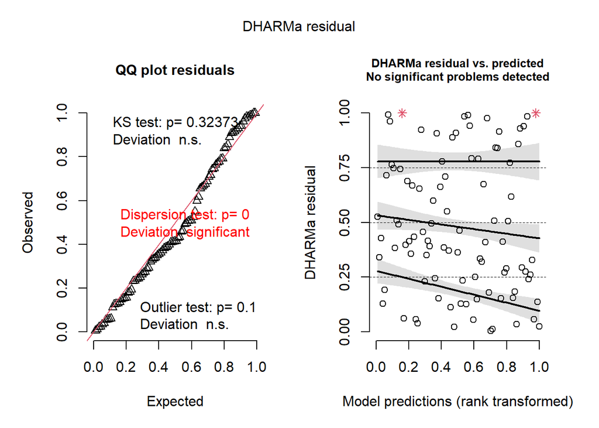

```
## Object of Class DHARMa with simulated residuals based on 250 simulations with refit = FALSE . See ?DHARMa::simulateResiduals for help.
##
## Scaled residual values: 0.03429555 0.3909649 0.3629404 0.02236689 0.356397 0.2311206 0.2336816 0.2710443 0.385886 0.428745 0.05798994 0.1826207 0.433612 0.1793212 0.01159758 0.3505102 0.06116024 0.1559253 0.2506516 0.3347125 ...
```

```r
simulateResiduals(cancer.glm, plot = T)
```

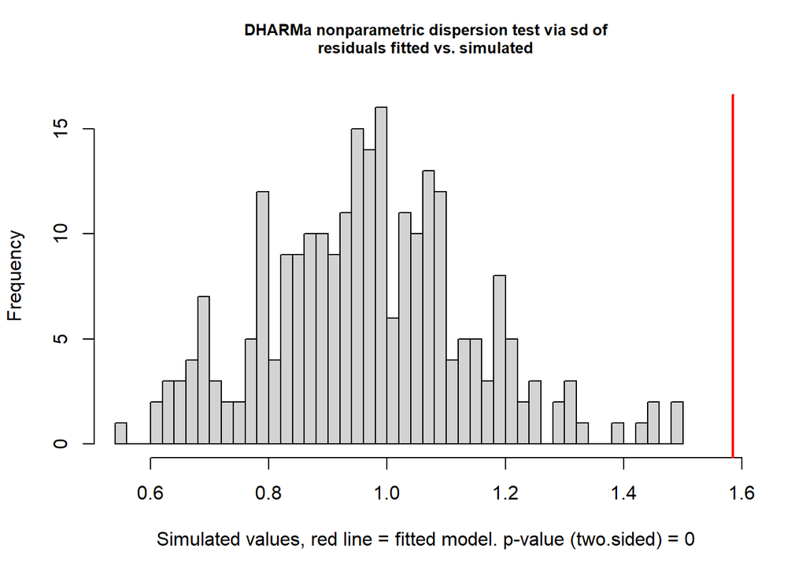

```
##
##  DHARMa nonparametric dispersion test via sd of residuals fitted vs.
##  simulated
##
## data:  simulationOutput
## dispersion = 1.6357, p-value < 2.2e-16
## alternative hypothesis: two.sided
```

```r
testDispersion(cancer.glm, plot = T)
```

```r
cancer.nb <- glm.nb(Cancers ~ Distance, data=cancer)
summary(cancer.nb)
```

```
##
## Call:
## glm.nb(formula = Cancers ~ Distance, data = cancer, init.theta = 1.359466981,
##     link = log)
##
## Coefficients:
##              Estimate Std. Error z value Pr(>|z|)
## (Intercept)  0.182490   0.252434   0.723    0.470
## Distance    -0.006041   0.004727  -1.278    0.201
##
## (Dispersion parameter for Negative Binomial(1.3595) family taken to be 1)
##
##     Null deviance: 96.647  on 93  degrees of freedom
## Residual deviance: 94.973  on 92  degrees of freedom
## AIC: 253.19
##
## Number of Fisher Scoring iterations: 1
##
##
##               Theta:  1.359
##           Std. Err.:  0.612
##
##  2 x log-likelihood:  -247.191
```

Test hypotheses and assess explanatory power:

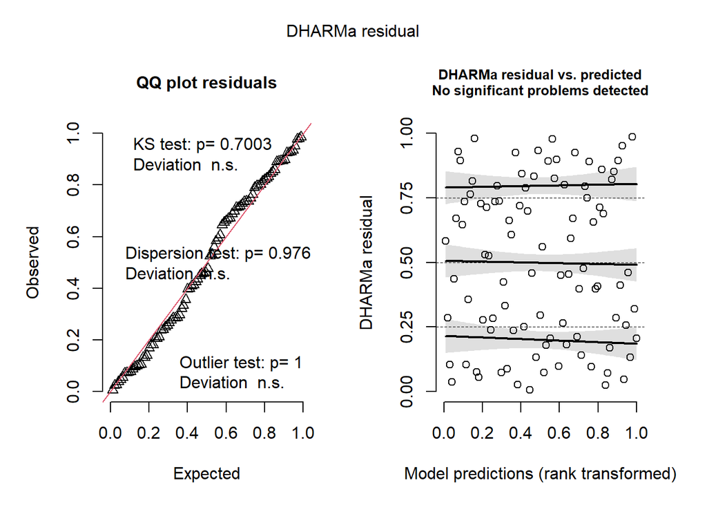

```
## Object of Class DHARMa with simulated residuals based on 250 simulations with refit = FALSE . See ?DHARMa::simulateResiduals for help.
##
## Scaled residual values: 0.1691706 0.08785123 0.2964165 0.1319477 0.5308209 0.07382625 0.1803357 0.3979211 0.2507544 0.1048807 0.1318335 0.07170322 0.5260157 0.2110324 0.1405788 0.424706 0.076321 0.02451732 0.4505731 0.1809262 ...
```

```r
simulateResiduals(cancer.nb, plot = T)
```

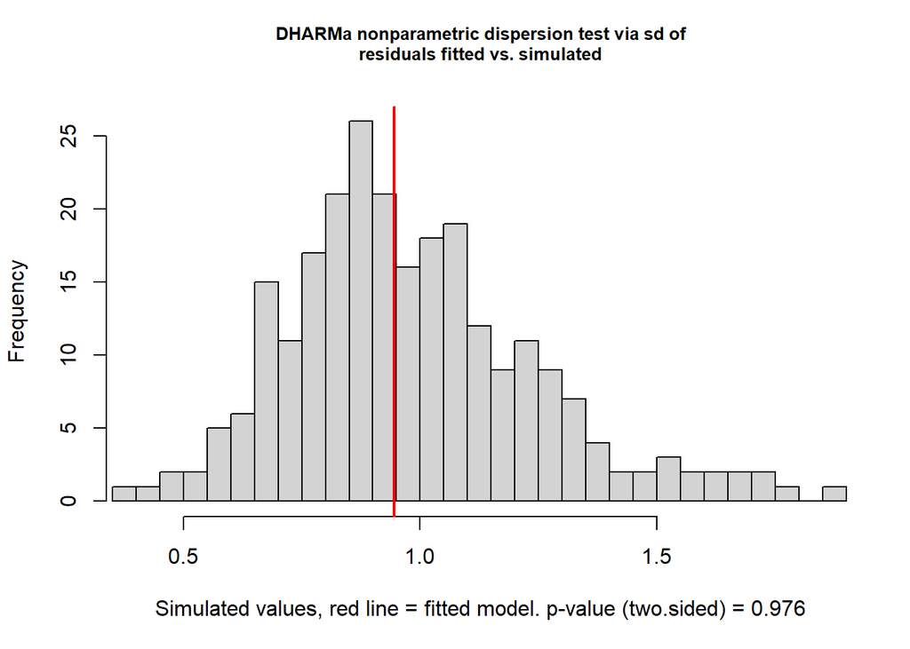

```
##
##  DHARMa nonparametric dispersion test via sd of residuals fitted vs.
##  simulated
##
## data:  simulationOutput
## dispersion = 0.96172, p-value = 0.976
## alternative hypothesis: two.sided
```

```r
testDispersion(cancer.nb, plot = T)
```

```r
anova(cancer.nb, test = "LRT")
```

```
## Analysis of Deviance Table
##
## Model: Negative Binomial(1.3595), link: log
##
## Response: Cancers
##
## Terms added sequentially (first to last)
##
##
##          Df Deviance Resid. Df Resid. Dev Pr(>Chi)
## NULL                        93     96.647
## Distance  1   1.6741        92     94.973   0.1957
```

```r
r2(cancer.nb)
```

```
## # R2 for Generalized Linear Regression
##   Nagelkerke's R2: 0.027
```

Communicate Results:

There is no significant relationship between number of cancer cases and distance from a nuclear power plant. (Chisq = 1.6741, p value 0.19). The model explained 2.7% of the variance. Based on these results, we cannot conclude that living closer to a power plant increases the number of reported cancer cases.

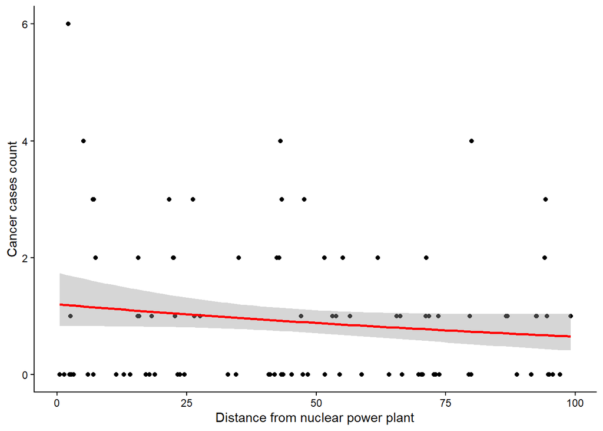

```r
ggplot(data = cancer, aes(x = Distance, y = Cancers)) +
  geom_point()+
  geom_smooth(method = "glm", method.args = list(family = "poisson"), color = "red") +
  labs(x =  "Distance from nuclear power plant", y = "Cancer cases count")+
  theme_classic()
```

*Question 3:* Use data(cbpp) from library(lme4) to model the number of cases of cattle plague (incidence) as a function of period. Control for herd size in your model. Analyze the data following this structure: 1. Question, 2. Exploratory analyses, 3. Fit model, 4. Validate model, 5. Test hypothesis and assess explanatory power, and 6. Communication of results (plot + description of main results).

Question: Is the number of cases of cattle plague influenced by time period or herd size?

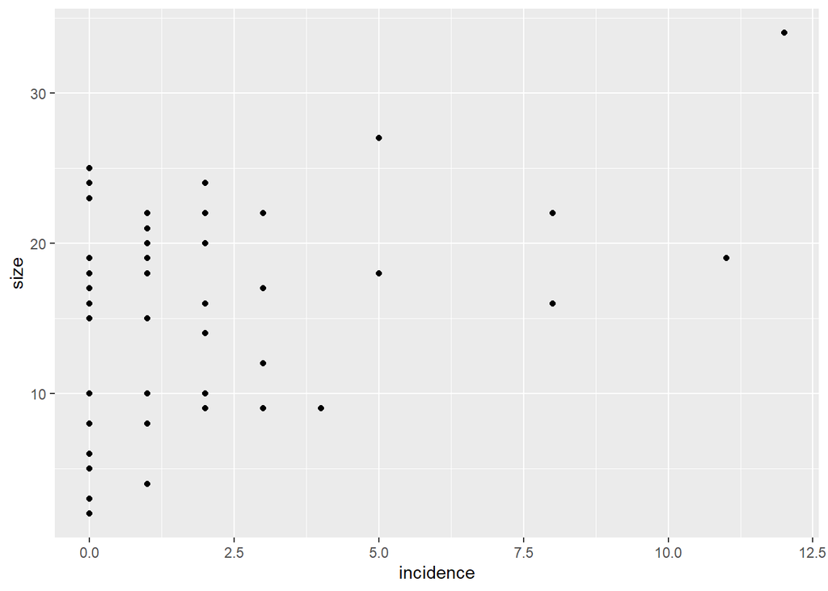

```r
#Exploratory analyses
plague <- cbpp

ggplot(plague, aes(x = incidence, y = size))+
  geom_point()
```

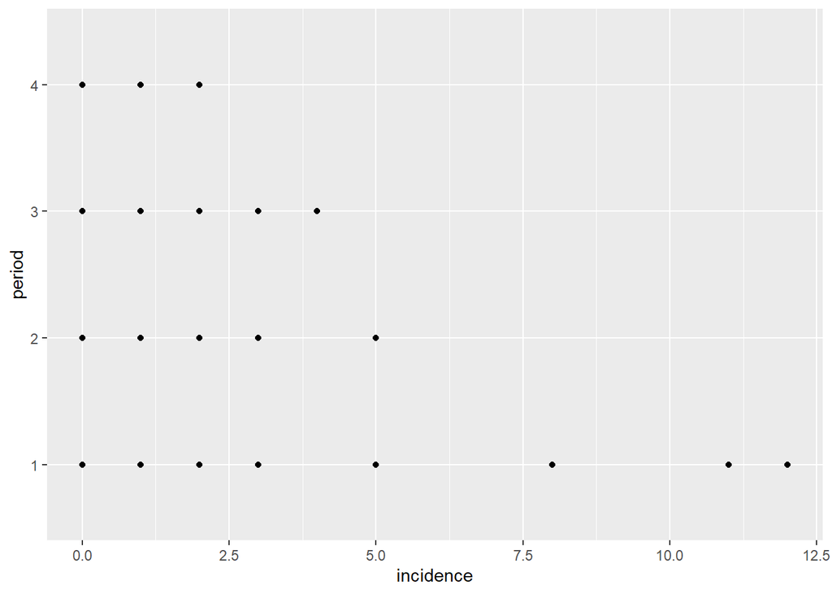

```r
ggplot(plague, aes(x = incidence, y = period))+
  geom_point()
```

Fit Model

```r
plague_glmm <- glmer(cbind(incidence, size - incidence) ~ period + (1 | herd),
                    data = plague,
                    family = binomial)
summary(plague_glmm)
```

```
## Generalized linear mixed model fit by maximum likelihood (Laplace
##   Approximation) [glmerMod]
##  Family: binomial  ( logit )
## Formula: cbind(incidence, size - incidence) ~ period + (1 | herd)
##    Data: plague
##
##       AIC       BIC    logLik -2*log(L)  df.resid
##     194.1     204.2     -92.0     184.1        51
##
## Scaled residuals:
##     Min      1Q  Median      3Q     Max
## -2.3816 -0.7889 -0.2026  0.5142  2.8791
##
## Random effects:
##  Groups Name        Variance Std.Dev.
##  herd   (Intercept) 0.4123   0.6421
## Number of obs: 56, groups:  herd, 15
##
## Fixed effects:
##             Estimate Std. Error z value Pr(>|z|)
## (Intercept)  -1.3983     0.2312  -6.048 1.47e-09 ***
## period2      -0.9919     0.3032  -3.272 0.001068 **
## period3      -1.1282     0.3228  -3.495 0.000474 ***
## period4      -1.5797     0.4220  -3.743 0.000182 ***
## ---
## Signif. codes:  0 '***' 0.001 '**' 0.01 '*' 0.05 '.' 0.1 ' ' 1
##
## Correlation of Fixed Effects:
##         (Intr) perid2 perid3
## period2 -0.363
## period3 -0.340  0.280
## period4 -0.260  0.213  0.198
```

Validate Model

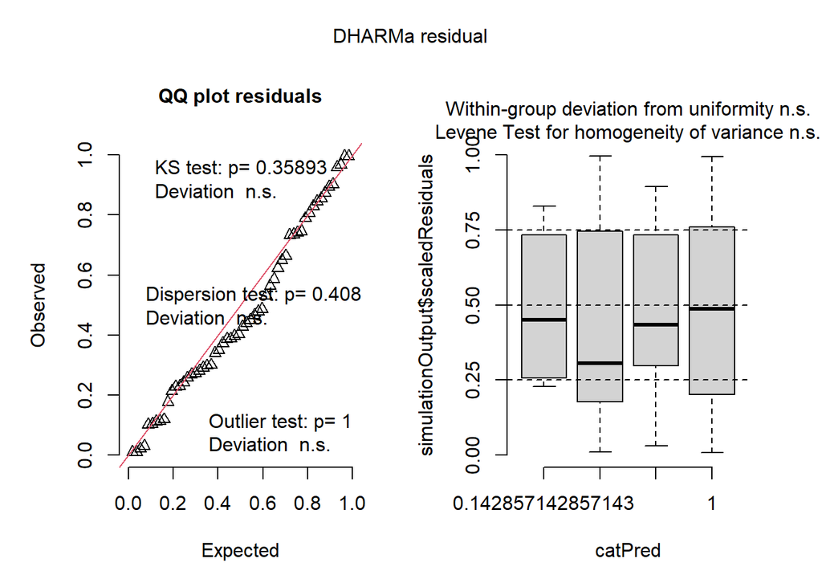

```
## Object of Class DHARMa with simulated residuals based on 250 simulations with refit = FALSE . See ?DHARMa::simulateResiduals for help.
##
## Scaled residual values: 0.3973751 0.8945491 0.9956805 0.402695 0.2901473 0.3724286 0.2717665 0.8740848 0.649741 0.2680626 0.8285526 0.4657061 0.2801929 0.9017911 0.2280075 0.6641468 0.03069543 0.111195 0.8066431 0.4864031 ...
```

```r
simulateResiduals(plague_glmm, plot = T)
```

Test hypothesis and assess explanatory power:

```r
drop1(plague_glmm, test = "Chisq")
```

```
## Single term deletions
##
## Model:
## cbind(incidence, size - incidence) ~ period + (1 | herd)
##        npar    AIC   LRT   Pr(Chi)
## <none>      194.05
## period    3 213.66 25.61 1.151e-05 ***
## ---
## Signif. codes:  0 '***' 0.001 '**' 0.01 '*' 0.05 '.' 0.1 ' ' 1
```

```r
r2(plague_glmm)
```

```
## # R2 for Mixed Models
##
##   Conditional R2: 0.776
##      Marginal R2: 0.354
```

Communicate Results: The model revealed a significant primary effect of period on disease incidence (chisq = 25.61, df = 3, p < 0.001). All subsequent periods after baseline (Period 1) showed a marked reduction in the probability of infection.

[output not shown]

[figure not shown]

```r
pred <- estimate_relation(plague_glmm) #modelbased
pred.farm <- estimate_relation(plague_glmm, include_random = T)

ggplot(pred.farm, aes(x=herd, y=Predicted, group=period))+
  geom_line(color="darkgrey", alpha=0.6)+
  geom_point(data = plague, aes(x=herd, y=size, color = period), size=0.9, alpha=0.6, position = position_jitter(width = 0, height = 0.05))+
  geom_line(data = pred, aes(x = period, y = Predicted, color=period), linewidth = 2)+
  geom_ribbon(data = pred, aes(x = period, ymin = CI_low, ymax = CI_high, fill=period), alpha = 0.2) +
  scale_color_manual(values=c("firebrick4", "dodgerblue3", "green", "pink"))+
  scale_fill_manual(values=c("firebrick4", "dodgerblue3", "green", "pink"))+
  facet_wrap(~period)+
  ylab("Herd size")+
  xlab("Incidence of plague")+
  theme_classic()
```

*Question 4:* Use insects.csv to model the number of insects (count) as an additive function (no interaction) of habitat (categorical) and flowers (numerical). Previous studies have reported that habitat quality tends to drive the detection of insects (some habitats have no insects regardless of flowers). Analyze the data following this structure: 1. Question, 2. Exploratory analyses, 3. Fit model, 4. Validate model, 5. Test hypothesis and assess explanatory power, and 6. Communication of results (plot + description of main results).

Question: Is the number of insects counted correlated with habitat type and number of flowers present?

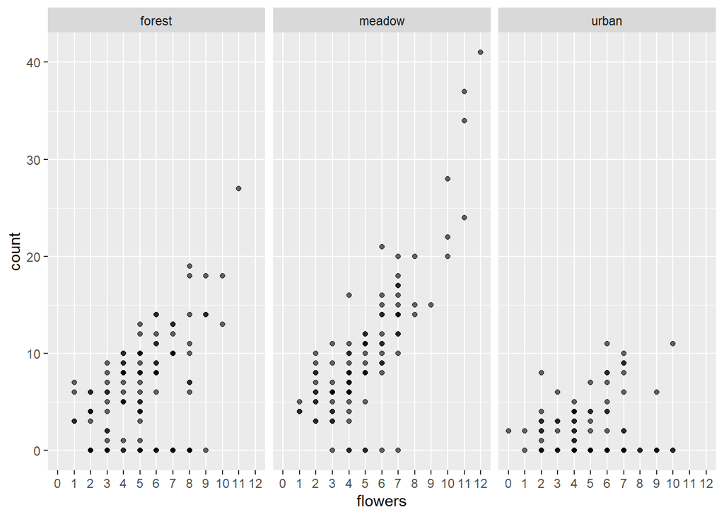

```r
#Exploratory analyses
insects <- read.csv("../data_raw/insects.csv", header = T)

insects$flowers <- as.factor(insects$flowers)

ggplot(insects, aes(x = flowers, y = count)) +
  geom_point(alpha = 0.6) +
  facet_wrap(~habitat)
```

Fit Model

```r
insect.model <- glm(count ~ habitat + flowers,
             family = poisson(link = "log"),
             data = insects)

summary(insect.model)
```

```
##
## Call:
## glm(formula = count ~ habitat + flowers, family = poisson(link = "log"),
##     data = insects)
##
## Coefficients:
##                Estimate Std. Error z value Pr(>|z|)
## (Intercept)    1.727205   0.711667   2.427   0.0152 *
## habitatmeadow  0.404957   0.051314   7.892 2.98e-15 ***
## habitaturban  -1.034057   0.080439 -12.855  < 2e-16 ***
## flowers1      -0.421007   0.730887  -0.576   0.5646
## flowers2      -0.375222   0.716056  -0.524   0.6003
## flowers3      -0.409323   0.715568  -0.572   0.5673
## flowers4      -0.111269   0.712661  -0.156   0.8759
## flowers5      -0.006932   0.713097  -0.010   0.9922
## flowers6       0.356208   0.712349   0.500   0.6170
## flowers7       0.427974   0.712420   0.601   0.5480
## flowers8       0.319648   0.715901   0.446   0.6552
## flowers9       0.542858   0.720150   0.754   0.4510
## flowers10      0.967842   0.716309   1.351   0.1766
## flowers11      1.372484   0.716918   1.914   0.0556 .
## flowers12      1.581411   0.728347   2.171   0.0299 *
## ---
## Signif. codes:  0 '***' 0.001 '**' 0.01 '*' 0.05 '.' 0.1 ' ' 1
##
## (Dispersion parameter for poisson family taken to be 1)
##
##     Null deviance: 1942.2  on 299  degrees of freedom
## Residual deviance: 1021.3  on 285  degrees of freedom
## AIC: 1895.9
##
## Number of Fisher Scoring iterations: 6
```

Validate Model

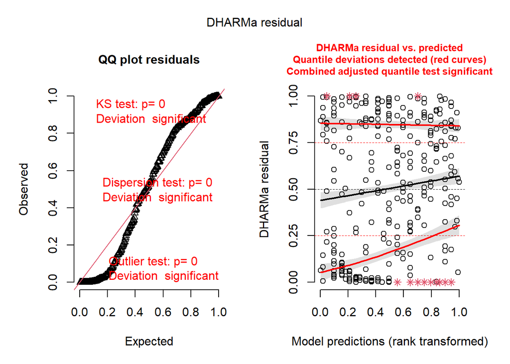

```
## Object of Class DHARMa with simulated residuals based on 250 simulations with refit = FALSE . See ?DHARMa::simulateResiduals for help.
##
## Scaled residual values: 0.9721663 0.9952952 0.05661004 0 0.02359015 0 0.977697 0.7060003 0.894754 0.8770763 0.7235438 0.4497601 0.4780905 0.6650903 0.9947536 0.6038474 0.1453485 0.03113314 0.6452366 0.8723046 ...
```

```r
simulateResiduals(insect.model, plot = T)
```

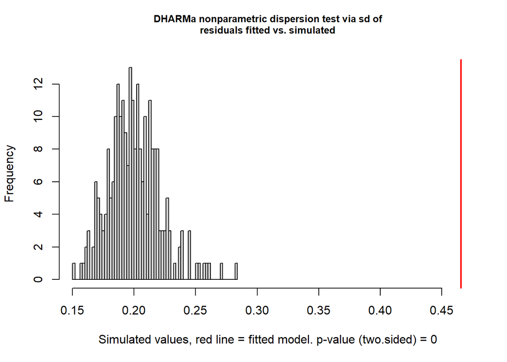

```
##
##  DHARMa nonparametric dispersion test via sd of residuals fitted vs.
##  simulated
##
## data:  simulationOutput
## dispersion = 2.3275, p-value < 2.2e-16
## alternative hypothesis: two.sided
```

```r
testDispersion(insect.model, plot = T)
```

```r
insect.nb <- glm.nb(count ~ habitat + flowers, data = insects)
summary(insect.nb)
```

```
##
## Call:
## glm.nb(formula = count ~ habitat + flowers, data = insects, init.theta = 1.681325785,
##     link = log)
##
## Coefficients:
##                Estimate Std. Error z value Pr(>|z|)
## (Intercept)    1.713116   1.055604   1.623  0.10462
## habitatmeadow  0.386761   0.122130   3.167  0.00154 **
## habitaturban  -1.019969   0.139751  -7.298 2.91e-13 ***
## flowers1      -0.389754   1.098248  -0.355  0.72267
## flowers2      -0.305255   1.064262  -0.287  0.77425
## flowers3      -0.355079   1.063829  -0.334  0.73855
## flowers4      -0.095646   1.057488  -0.090  0.92793
## flowers5      -0.008474   1.059430  -0.008  0.99362
## flowers6       0.410194   1.058891   0.387  0.69847
## flowers7       0.458430   1.059794   0.433  0.66533
## flowers8       0.261407   1.072687   0.244  0.80747
## flowers9       0.431862   1.090259   0.396  0.69202
## flowers10      0.917466   1.090616   0.841  0.40022
## flowers11      1.416251   1.126360   1.257  0.20862
## flowers12      1.613694   1.316694   1.226  0.22036
## ---
## Signif. codes:  0 '***' 0.001 '**' 0.01 '*' 0.05 '.' 0.1 ' ' 1
##
## (Dispersion parameter for Negative Binomial(1.6813) family taken to be 1)
##
##     Null deviance: 573.61  on 299  degrees of freedom
## Residual deviance: 392.62  on 285  degrees of freedom
## AIC: 1657.9
##
## Number of Fisher Scoring iterations: 1
##
##
##               Theta:  1.681
##           Std. Err.:  0.242
##
##  2 x log-likelihood:  -1625.875
```

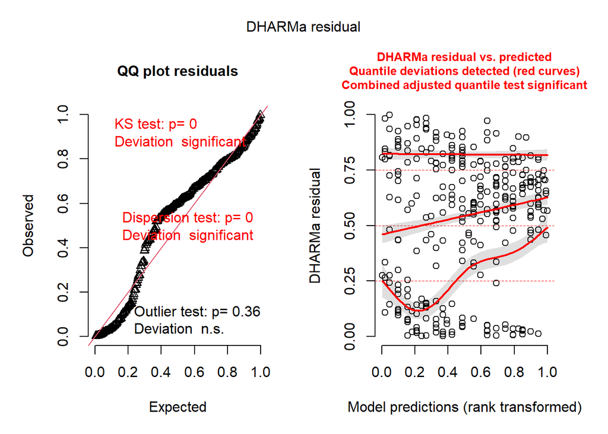

```
## Object of Class DHARMa with simulated residuals based on 250 simulations with refit = FALSE . See ?DHARMa::simulateResiduals for help.
##
## Scaled residual values: 0.9082557 0.948524 0.02658686 0.004291104 0.1507343 0.03377684 0.8970867 0.6043074 0.8592396 0.8234332 0.7129543 0.707108 0.6383224 0.6982341 0.9329955 0.557815 0.264927 0.1909737 0.6739027 0.7727186 ...
```

```r
simulateResiduals(insect.nb, plot = T)
```

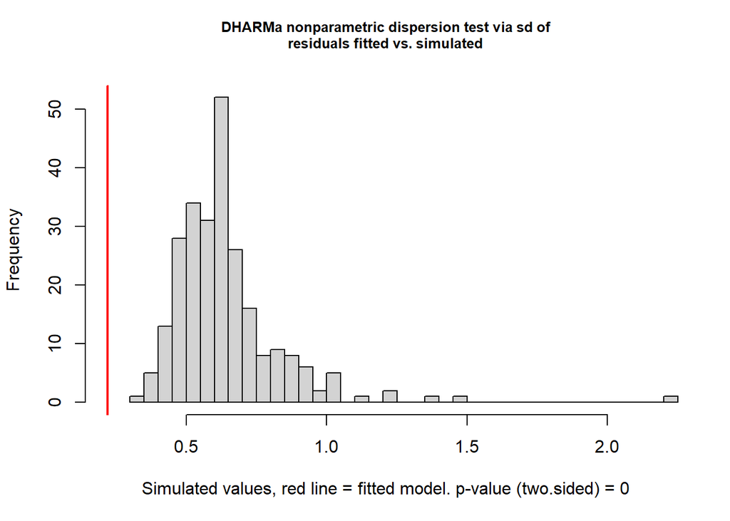

```
##
##  DHARMa nonparametric dispersion test via sd of residuals fitted vs.
##  simulated
##
## data:  simulationOutput
## dispersion = 0.34282, p-value < 2.2e-16
## alternative hypothesis: two.sided
```

```r
testDispersion(insect.nb, plot = T)
```

```r
insect_nbzi<-glmmTMB(count ~ habitat + flowers, ziformula = ~habitat, family=nbinom1, data=insects)
summary(insect_nbzi)
```

```
##  Family: nbinom1  ( log )
## Formula:          count ~ habitat + flowers
## Zero inflation:         ~habitat
## Data: insects
##
##       AIC       BIC    logLik -2*log(L)  df.resid
##        NA        NA        NA        NA       281
##
##
## Dispersion parameter for nbinom1 family (): 1.44e-09
##
## Conditional model:
##               Estimate Std. Error z value Pr(>|z|)
## (Intercept)    1.26772    0.71214   1.780  0.07505 .
## habitatmeadow  0.22978    0.05142   4.469 7.87e-06 ***
## habitaturban  -0.57458    0.08308  -6.916 4.64e-12 ***
## flowers1       0.13106    0.73168   0.179  0.85784
## flowers2       0.34211    0.71628   0.478  0.63292
## flowers3       0.31164    0.71605   0.435  0.66340
## flowers4       0.56477    0.71307   0.792  0.42834
## flowers5       0.71358    0.71373   1.000  0.31741
## flowers6       1.03749    0.71260   1.456  0.14542
## flowers7       1.18615    0.71264   1.664  0.09602 .
## flowers8       1.21493    0.71659   1.695  0.08999 .
## flowers9       1.36378    0.72113   1.891  0.05860 .
## flowers10      1.60422    0.71703   2.237  0.02527 *
## flowers11      1.97291    0.71728   2.751  0.00595 **
## flowers12      2.21607    0.72868   3.041  0.00236 **
## ---
## Signif. codes:  0 '***' 0.001 '**' 0.01 '*' 0.05 '.' 0.1 ' ' 1
##
## Zero-inflation model:
##               Estimate Std. Error z value Pr(>|z|)
## (Intercept)    -1.1577     0.2228  -5.197 2.02e-07 ***
## habitatmeadow  -1.4137     0.4531  -3.120 0.001808 **
## habitaturban    1.0697     0.3101   3.449 0.000563 ***
## ---
## Signif. codes:  0 '***' 0.001 '**' 0.01 '*' 0.05 '.' 0.1 ' ' 1
```

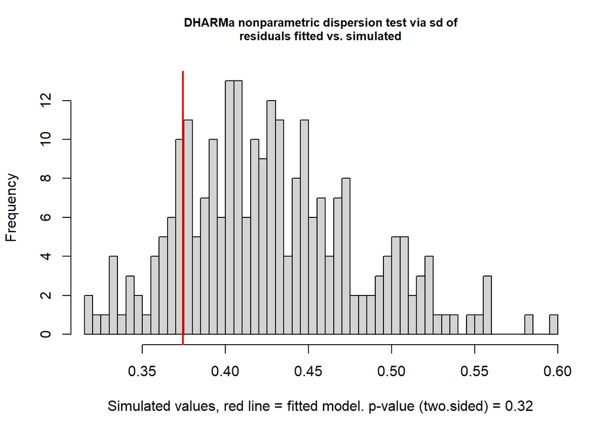

```
##
##  DHARMa nonparametric dispersion test via sd of residuals fitted vs.
##  simulated
##
## data:  simulationOutput
## dispersion = 0.87613, p-value = 0.32
## alternative hypothesis: two.sided
```

```r
testDispersion(insect_nbzi, plot = T)
```

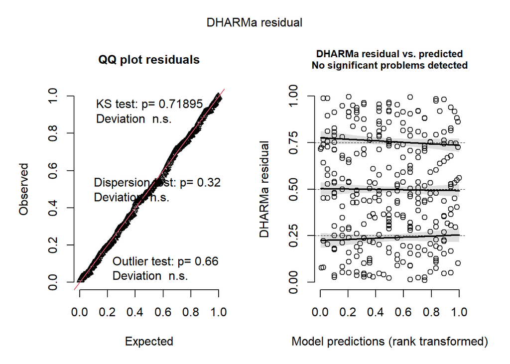

```
## Object of Class DHARMa with simulated residuals based on 250 simulations with refit = FALSE . See ?DHARMa::simulateResiduals for help.
##
## Scaled residual values: 0.8253754 0.9485678 0.1587038 0.087693 0.4285968 0.01111656 0.9168641 0.4918941 0.7529175 0.7647228 0.7306421 0.5475339 0.4721877 0.6511348 0.9375498 0.5026217 0.2217813 0.03633187 0.4369733 0.788721 ...
```

```r
simulateResiduals(insect_nbzi, plot = T)
```

Test hypotheses and assess explanatory power:

```r
drop1(insect_nbzi, test = "Chisq")
```

```
## Single term deletions
##
## Model:
## count ~ habitat + flowers
##         Df    AIC LRT Pr(>Chi)
## <none>
## habitat  2 1485.9
## flowers 12 1586.5
```

```r
Anova(insect_nbzi, type = 2, test = "Chisq")
```

```
## Analysis of Deviance Table (Type II Wald chisquare tests)
##
## Response: count
##          Chisq Df Pr(>Chisq)
## habitat 105.00  2  < 2.2e-16 ***
## flowers 448.78 12  < 2.2e-16 ***
## ---
## Signif. codes:  0 '***' 0.001 '**' 0.01 '*' 0.05 '.' 0.1 ' ' 1
```

```r
r2(insect_nbzi)
```

```
## # R2 for Zero-Inflated and Hurdle Regression
##        R2: 0.960
##   adj. R2: 0.958
```

Communicate Results: Insect abundance varied significantly as a function of both habitat type and flower abundance. Habitat had a significant effect on insect counts (p < 0.001). Flower abundance was also a significant predictor of insect count (p < 0.001). The model explained 96% of the variability in insect count.

```r
pred <- estimate_relation(insect_nbzi, length = 100)
```

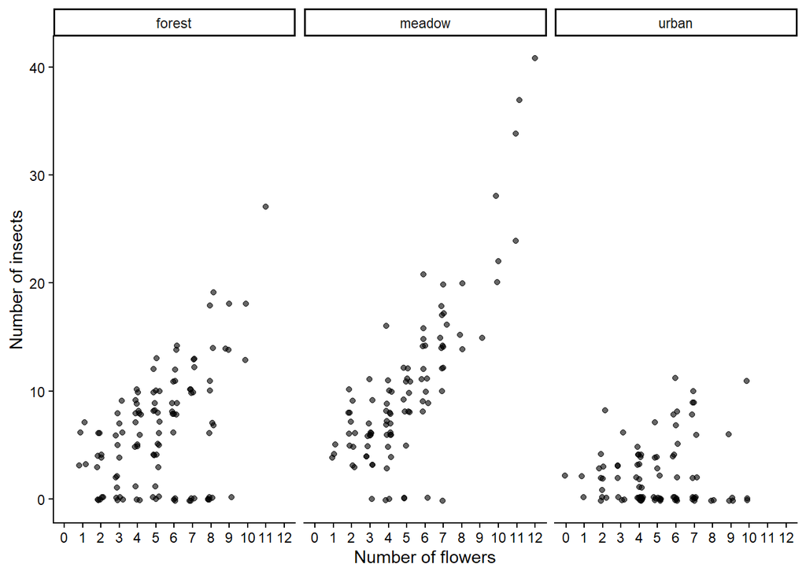

```r
ggplot(pred, aes(x = flowers, y = Predicted)) +

  geom_point(data = insects,
             aes(x = flowers, y = count),
             color = "black",
             alpha = 0.6,
             position = position_jitter(width = 0.2, height = 0.2)) +

  facet_wrap(~habitat) +

  ylab("Number of insects") +
  xlab("Number of flowers") +

  theme_classic()
```